# Analisis del transito de bicicletas públicas en CABA

Ezequiel

17/01/2022

Se utilizaran las siguientes librerías:

```r
library(tidyverse)
```

```r
library(ggplot2)
library(dplyr)

library(corrplot) #para hacer una matriz de correlación
```

Lectura de los datasets:

```r
#datos de EcoBici
df <- read_csv("trips_2021.csv")
#datos de https://www.visualcrossing.com/ relacionados a condiciones climáticas.

clima_primera_parte <- read_csv("temp_1ene-1jun.csv")
clima_segunda_parte <- read_csv("temp_2jun-3dic.csv")
clima <- rbind(clima_primera_parte,clima_segunda_parte)

summary(df)
```

```
##  id_recorrido       duracion_recorrido fecha_origen_recorrido
##  Length:2649845     Min.   :      61   Length:2649845
##  Class :character   1st Qu.:     640   Class :character
##  Mode  :character   Median :    1015   Mode  :character
##                     Mean   :    1235
##                     3rd Qu.:    1533
##                     Max.   :13515225
##  id_estacion_origen nombre_estacion_origen direccion_estacion_origen
##  Length:2649845     Length:2649845         Length:2649845
##  Class :character   Class :character       Class :character
##  Mode  :character   Mode  :character       Mode  :character
##
##
##
##  long_estacion_origen lat_estacion_origen fecha_destino_recorrido
##  Min.   :-58.52       Min.   :-34.68      Length:2649845
##  1st Qu.:-58.44       1st Qu.:-34.61      Class :character
##  Median :-58.42       Median :-34.60      Mode  :character
##  Mean   :-58.42       Mean   :-34.60
##  3rd Qu.:-58.40       3rd Qu.:-34.58
##  Max.   :-58.36       Max.   :-34.54
##  id_estacion_destino nombre_estacion_destino direccion_estacion_destino
##  Length:2649845      Length:2649845          Length:2649845
##  Class :character    Class :character        Class :character
##  Mode  :character    Mode  :character        Mode  :character
##
##
##
##  long_estacion_destino lat_estacion_destino  id_usuario
##  Min.   :-58.52        Min.   :-34.68       Length:2649845
##  1st Qu.:-58.44        1st Qu.:-34.61       Class :character
##  Median :-58.42        Median :-34.60       Mode  :character
##  Mean   :-58.42        Mean   :-34.60
##  3rd Qu.:-58.40        3rd Qu.:-34.58
##  Max.   :-58.36        Max.   :-34.54
##  modelo_bicicleta
##  Length:2649845
##  Class :character
##  Mode  :character
##
##
##
```

```r
summary(clima)
```

```
##      name              datetime             tempmax         tempmin
##  Length:337         Min.   :2021-01-01   Min.   : 8.00   Min.   : 3.5
##  Class :character   1st Qu.:2021-03-26   1st Qu.:16.40   1st Qu.:10.7
##  Mode  :character   Median :2021-06-18   Median :21.10   Median :14.4
##                     Mean   :2021-06-18   Mean   :21.03   Mean   :14.5
##                     3rd Qu.:2021-09-10   3rd Qu.:25.00   3rd Qu.:18.8
##                     Max.   :2021-12-03   Max.   :35.30   Max.   :26.7
##
##       temp        feelslikemax    feelslikemin     feelslike
##  Min.   : 6.80   Min.   : 6.20   Min.   : 1.10   Min.   : 4.40
##  1st Qu.:13.60   1st Qu.:16.40   1st Qu.:10.70   1st Qu.:13.60
##  Median :17.50   Median :21.10   Median :14.40   Median :17.50
##  Mean   :17.66   Mean   :21.14   Mean   :14.22   Mean   :17.58
##  3rd Qu.:21.80   3rd Qu.:25.00   3rd Qu.:18.80   3rd Qu.:21.80
##  Max.   :28.90   Max.   :36.50   Max.   :27.80   Max.   :30.70
##
##       dew           humidity         precip        precipprob
##  Min.   :-2.70   Min.   :33.00   Min.   :  0.000   Mode:logical
##  1st Qu.: 8.10   1st Qu.:62.79   1st Qu.:  0.000   NA's:337
##  Median :12.60   Median :72.54   Median :  0.000
##  Mean   :11.97   Mean   :71.38   Mean   :  3.228
##  3rd Qu.:16.30   3rd Qu.:80.78   3rd Qu.:  0.300
##  Max.   :21.90   Max.   :96.31   Max.   :182.500
##                                  NA's   :1
##   precipcover     preciptype       snow           snowdepth
##  Min.   : 0.000   Mode:logical   Mode:logical   Min.   :0.0000
##  1st Qu.: 0.000   NA's:337       NA's:337       1st Qu.:0.0000
##  Median : 0.000                                 Median :0.0000
##  Mean   : 2.505                                 Mean   :0.2097
##  3rd Qu.: 4.170                                 3rd Qu.:0.0000
##  Max.   :16.670                                 Max.   :6.2800
##  NA's   :1                                      NA's   :154
##     windgust       windspeed        winddir      sealevelpressure
##  Min.   : 9.70   Min.   : 7.60   Min.   : 33.8   Min.   : 997.1
##  1st Qu.:37.10   1st Qu.:15.90   1st Qu.: 90.8   1st Qu.:1013.0
##  Median :42.50   Median :20.10   Median :140.0   Median :1016.3
##  Mean   :43.08   Mean   :21.23   Mean   :152.7   Mean   :1016.4
##  3rd Qu.:50.00   3rd Qu.:26.20   3rd Qu.:206.1   3rd Qu.:1020.0
##  Max.   :64.80   Max.   :43.10   Max.   :324.5   Max.   :1031.6
##  NA's   :226                                     NA's   :2
```

[output cut: 17 more lines]

```
##  Min.   :2021-01-01 20:09:43   Min.   :0.0000   Length:337
##  1st Qu.:2021-03-26 18:56:00   1st Qu.:0.2500   Class :character
##  Median :2021-06-18 17:49:48   Median :0.5100   Mode  :character
##  Mean   :2021-06-18 18:51:08   Mean   :0.5108
##  3rd Qu.:2021-09-10 18:41:45   3rd Qu.:0.7700
##  Max.   :2021-12-03 19:53:34   Max.   :1.0000
##
##  description            icon             stations
##  Length:337         Length:337         Length:337
##  Class :character   Class :character   Class :character
##  Mode  :character   Mode  :character   Mode  :character
##
##
##
##
```

#Limpieza de los datos

Creamos la columna “recorrido_minutos”.

```r
df <- mutate(df, recorrido_minutos = round(df$duracion_recorrido /60,2))
```

Veamos los cuartiles y un boxplot para entender mejor la distribución de los recorridos.

```r
summary(df$recorrido_minutos)
```

```
##      Min.   1st Qu.    Median      Mean   3rd Qu.      Max.
##      1.02     10.67     16.92     20.59     25.55 225253.75
```

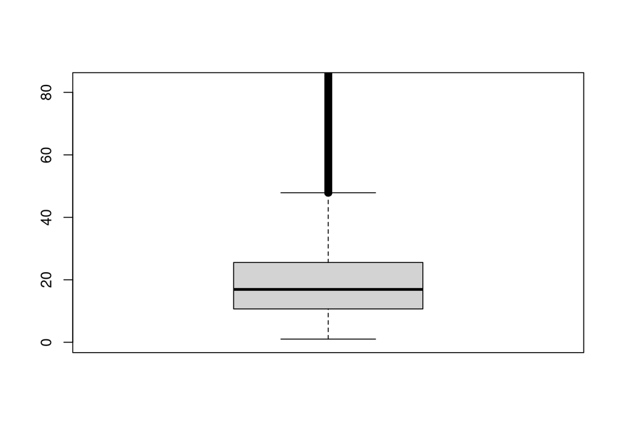

```r
boxplot(df$recorrido_minutos, ylim = c(0,83))
```

```r
quantile(df$recorrido_minutos, 0.99)
```

```
##   99%
## 76.07
```

```r
df <-filter(df, recorrido_minutos <= 76.07)
summary(df$recorrido_minutos)
```

```
##    Min. 1st Qu.  Median    Mean 3rd Qu.    Max.
##    1.02   10.62   16.77   19.26   25.23   76.07
```

```r
summary(df)
```

```
##  id_recorrido       duracion_recorrido fecha_origen_recorrido
##  Length:2623347     Min.   :  61       Length:2623347
##  Class :character   1st Qu.: 637       Class :character
##  Mode  :character   Median :1006       Mode  :character
##                     Mean   :1156
##                     3rd Qu.:1514
##                     Max.   :4564
##  id_estacion_origen nombre_estacion_origen direccion_estacion_origen
##  Length:2623347     Length:2623347         Length:2623347
##  Class :character   Class :character       Class :character
##  Mode  :character   Mode  :character       Mode  :character
##
##
##
##  long_estacion_origen lat_estacion_origen fecha_destino_recorrido
##  Min.   :-58.52       Min.   :-34.68      Length:2623347
##  1st Qu.:-58.44       1st Qu.:-34.61      Class :character
##  Median :-58.42       Median :-34.60      Mode  :character
##  Mean   :-58.42       Mean   :-34.60
##  3rd Qu.:-58.40       3rd Qu.:-34.58
##  Max.   :-58.36       Max.   :-34.54
##  id_estacion_destino nombre_estacion_destino direccion_estacion_destino
##  Length:2623347      Length:2623347          Length:2623347
##  Class :character    Class :character        Class :character
##  Mode  :character    Mode  :character        Mode  :character
##
##
##
##  long_estacion_destino lat_estacion_destino  id_usuario
##  Min.   :-58.52        Min.   :-34.68       Length:2623347
##  1st Qu.:-58.44        1st Qu.:-34.61       Class :character
##  Median :-58.42        Median :-34.60       Mode  :character
##  Mean   :-58.42        Mean   :-34.60
##  3rd Qu.:-58.40        3rd Qu.:-34.58
##  Max.   :-58.36        Max.   :-34.54
##  modelo_bicicleta   recorrido_minutos
##  Length:2623347     Min.   : 1.02
##  Class :character   1st Qu.:10.62
##  Mode  :character   Median :16.77
##                     Mean   :19.26
##                     3rd Qu.:25.23
##                     Max.   :76.07
```

Buscamos valores vacíos en el dataset:

```r
apply(is.na(df),2,sum)
```

```
##               id_recorrido         duracion_recorrido
##                          0                          0
##     fecha_origen_recorrido         id_estacion_origen
##                          0                          0
##     nombre_estacion_origen  direccion_estacion_origen
##                          0                          0
##       long_estacion_origen        lat_estacion_origen
##                          0                          0
##    fecha_destino_recorrido        id_estacion_destino
##                          0                          0
##    nombre_estacion_destino direccion_estacion_destino
##                          0                          0
##      long_estacion_destino       lat_estacion_destino
##                          0                          0
##                 id_usuario           modelo_bicicleta
##                          0                          0
##          recorrido_minutos
##                          0
```

No hay ninguna observacion vacía en df.

#Análisis de los Datos

Hagamos una comparación según temporadas de la demanda. Para eso clasifiquemos cada viaje según estas:

```r
#cargamos la fecha correspondiente a cada cambio de estación.
    inv <- as.Date("2021-06-21", format = "%Y-%m-%d")
    prim <- as.Date("2021-09-22",  format = "%Y-%m-%d")
    ver <- as.Date("2021-12-21",  format = "%Y-%m-%d")
    oto <- as.Date("2021-03-20",  format = "%Y-%m-%d")

#según la fecha en la que ocurre el viaje, clasificamos a este según su estación.
df <- df %>%
  mutate(temporada = case_when(
                                 as.Date(df$fecha_origen_recorrido,  format = "%Y-%m-%d") >= inv & as.Date(df$fecha_origen_recorrido,  format = "%Y-%m-%d") < prim ~ "invierno",
                                 as.Date(df$fecha_origen_recorrido,  format = "%Y-%m-%d") >= prim & as.Date(df$fecha_origen_recorrido,  format = "%Y-%m-%d")< ver ~ "primavera",
                                 as.Date(df$fecha_origen_recorrido,  format = "%Y-%m-%d") >= oto & as.Date(df$fecha_origen_recorrido,  format = "%Y-%m-%d") < inv ~ "otoño",
                                 as.Date(df$fecha_origen_recorrido,  format = "%Y-%m-%d")>= ver | as.Date(df$fecha_origen_recorrido,  format = "%Y-%m-%d") < oto ~ "verano"))
 df[570820,]
```

```
## # A tibble: 1 × 18
##   id_recorrido      duracion_recorrido fecha_origen_recorrido  id_estacion_orig…
##   <chr>                          <dbl> <chr>                   <chr>
## 1 12607435BAEcobici                476 2021-11-10 12:36:02 UTC 2BAEcobici
## # … with 14 more variables: nombre_estacion_origen <chr>,
## #   direccion_estacion_origen <chr>, long_estacion_origen <dbl>,
## #   lat_estacion_origen <dbl>, fecha_destino_recorrido <chr>,
## #   id_estacion_destino <chr>, nombre_estacion_destino <chr>,
## #   direccion_estacion_destino <chr>, long_estacion_destino <dbl>,
## #   lat_estacion_destino <dbl>, id_usuario <chr>, modelo_bicicleta <chr>,
## #   recorrido_minutos <dbl>, temporada <chr>
```

```r
viajes_por_temporada = df %>%
group_by(temporada) %>%
summarise(cantidad= n())

ordenEstacionario <- c("verano", "otoño", "invierno", "primavera")

viajes_por_temporada <- viajes_por_temporada[match(ordenEstacionario, viajes_por_temporada$temporada), ]

#Esta función es completamente secundaria, la utilizamos para anular la notación científica en la sesión de R.
options(scipen = 100)
```

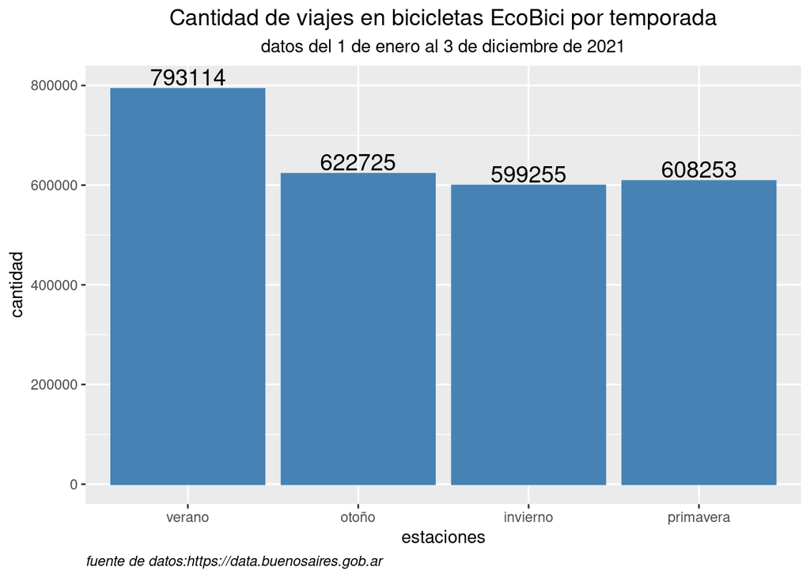

```r
ggplot(data = viajes_por_temporada, aes(x=factor(temporada, levels = temporada), y=cantidad)) +
       geom_bar(stat="identity", position = "dodge", color = "steelblue", fill = "steelblue") +
       geom_text(aes(label = cantidad), vjust = -0.2, size = 5, position = position_dodge(0.9)) +
       ylim(0, 800000) +
       labs(title = "Cantidad de viajes en bicicletas EcoBici por temporada",
            subtitle = "datos del 1 de enero al 3 de diciembre de 2021",
            caption = "fuente de datos:https://data.buenosaires.gob.ar") +
            xlab("estaciones") +
            ylab("cantidad") +
       theme(plot.title = element_text(hjust = 0.5, size = 14),
             plot.subtitle = element_text(hjust = 0.5),
             plot.caption = element_text(hjust = 0, face = "italic")
  )
```

Se puede ver que la estación con mayor cantidad de viajes registrados es el verano, a pesar de que los datos apenas llegan al 3 de diciembre. Para las demás estaciones la demanda es muy similar.

Veamos ahora cómo es la cantidad de viajes registrada según el día de semana. Creamos distintos datasets por temporada y los agrupamos según el día de la semana en que estos ocurrieron:

```r
#creamos la columna "dia", que registra el dia de la semana en la que ocurrió el viaje:
df <- df %>% mutate(dia = weekdays(as.Date(df$fecha_origen_recorrido)))

ordenSemana <- c("lunes", "martes", "miércoles", "jueves", "viernes", "sábado", "domingo")
#agrupamos por dia y por estación:
semanales_verano = subset(df, df$temporada == "verano")
semanales_verano = semanales_verano %>%
group_by(dia) %>%
summarise(cantidad= n()) %>%
mutate(estacion = "verano")
#ordenamos:
semanales_verano = semanales_verano[match(ordenSemana, semanales_verano$dia), ]

#hacemos lo mismo para las demás temporadas:

semanales_otoño = subset(df, df$temporada == "otoño")
semanales_otoño = semanales_otoño %>%
group_by(dia) %>%
summarise(cantidad= n()) %>%
mutate(estacion = "otoño")

semanales_otoño = semanales_otoño[match(ordenSemana, semanales_otoño$dia), ]

semanales_invierno = subset(df, df$temporada == "invierno")
semanales_invierno = semanales_invierno %>%
group_by(dia) %>%
summarise(cantidad= n()) %>%
mutate(estacion = "invierno")

semanales_invierno = semanales_invierno[match(ordenSemana, semanales_invierno$dia), ]

semanales_primavera = subset(df, df$temporada == "primavera")
semanales_primavera = semanales_primavera  %>%
group_by(dia) %>%
summarise(cantidad= n()) %>%
mutate(estacion = "primavera")

semanales_primavera = semanales_primavera[match(ordenSemana, semanales_primavera$dia), ]
#teniendo los datasets separados por estación se podría realizar un análisis mas puntual. Por ahora trabajemos con la unión de ellos:
cantidades_por_estacion <- rbind(semanales_verano, semanales_otoño, semanales_invierno, semanales_primavera)
```

Veamos cómo queda el siguiente gráfico:

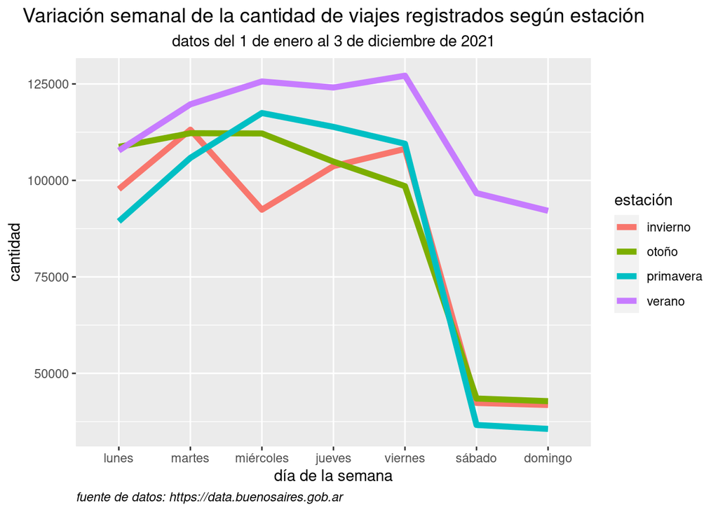

```r
ggplot(cantidades_por_estacion, aes(x = factor(dia, levels = ordenSemana), y = cantidad, group =factor(estacion))) +
  geom_line(size = 1, color = "gray") +
  geom_line(data = cantidades_por_estacion,
            aes(x = dia, y = cantidad, group = estacion, color = factor(estacion)),
            size = 2) +
  labs(title = "Variación semanal de la cantidad de viajes registrados según estación",
       subtitle = "datos del 1 de enero al 3 de diciembre de 2021",
       caption = "fuente de datos: https://data.buenosaires.gob.ar",
       color = "estación") +
  xlab("día de la semana") + ylab("cantidad") +
  theme(
    plot.title = element_text(hjust = 0.5, size = 14),
    plot.subtitle = element_text(hjust = 0.5),
    plot.caption = element_text(hjust = 0, face = "italic")
    )
```

Se encuentra un gran descenso en los fines de semana, fenómeno que se puede atribuir a que en estos días hay menos tránsito relacionado a la actividad laboral y además no hay viajes gratuitos. El verano no solo se mantiene mas alto respecto a las demás estaciones, sino que también es mas “resistente” a la baja en la cantidad de viajes registrados que se da para las demás estaciones durante los fines de semana.

Veamos cómo es la variación de la cantidad de viajes registrados según la hora del día. Volvemos a generar datasets según temporada, pero esta vez agrypamos según la hora en la que se dio el viaje.

```r
#primero creamos la columna que tiene la hora en la que ocurrió el viaje:
df <- df %>% mutate(hora_origen = as.POSIXlt(df$fecha_origen_recorrido)$hour)

ordenDia <- c(6,7,8,9,10,11,12,13,14,15,16,17,18,19,20,21,22,23,0,1,2,3,4,5)
#agrupamos por dia y por estacion:
diarias_verano = subset(df, df$temporada == "verano")
diarias_verano = diarias_verano %>%
group_by(hora_origen) %>%
summarise(cantidad= n()) %>%
mutate(estacion = "verano")
#ordenamos:
diarias_verano = diarias_verano[match(ordenDia, diarias_verano$hora_origen), ]

#otra vez, volvemos a hacer el mismo procedimiento para las demás estaciones.
diarias_otoño = subset(df, df$temporada == "otoño")
diarias_otoño = diarias_otoño %>%
group_by(hora_origen) %>%
summarise(cantidad= n()) %>%
mutate(estacion = "otoño")

diarias_otoño = diarias_otoño[match(ordenDia, diarias_otoño$hora_origen), ]

diarias_invierno = subset(df, df$temporada == "invierno")
diarias_invierno = diarias_invierno %>%
group_by(hora_origen) %>%
summarise(cantidad= n()) %>%
mutate(estacion = "invierno")

diarias_invierno = diarias_invierno[match(ordenDia, diarias_invierno$hora_origen), ]

diarias_primavera = subset(df, df$temporada == "primavera")
diarias_primavera = diarias_primavera %>%
group_by(hora_origen) %>%
summarise(cantidad= n()) %>%
mutate(estacion = "primavera")

diarias_primavera = diarias_primavera[match(ordenDia, diarias_primavera$hora_origen), ]

cantidades_por_hora <- rbind(diarias_verano, diarias_otoño, diarias_invierno, diarias_primavera)
```

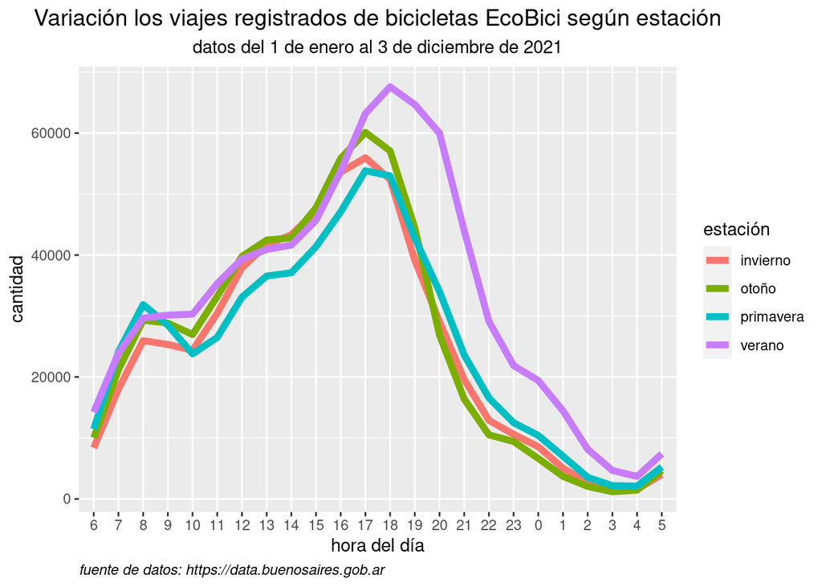

```r
ggplot(cantidades_por_hora, aes(x = factor(hora_origen, levels = ordenDia), y = cantidad, group =factor(estacion))) +
  geom_line(data = cantidades_por_hora,
            aes(x = factor(hora_origen, levels = ordenDia), y = cantidad, group = estacion, color = factor(estacion)),
            size = 2) +
  labs(title = "Variación los viajes registrados de bicicletas EcoBici según estación",
       subtitle = "datos del 1 de enero al 3 de diciembre de 2021",
       caption = "fuente de datos: https://data.buenosaires.gob.ar",
       color = "estación") +
  xlab("hora del día") + ylab("cantidad") +
  theme(
    plot.title = element_text(hjust = 0.5, size = 14),
    plot.subtitle = element_text(hjust = 0.5),
    plot.caption = element_text(hjust = 0, face = "italic")
    )
```

Se encuentra un comportamiento similar para las distintas temporadas, con la salvedad de que el otoño, el invierno y la primavera tienen su pico cerca de las 17 y el verano lo tiene “retrasado” a las 18. Otra particularidad es que la primavera registra una menor cantidad de viajes que el invierno entre las 10 y las 18, a pesar de que se dieron mas viajes en la primera que en la segunda.

Continuemos analizando las condiciones climáticas. Agrupamos por fecha en la que se dio el origen del recorrido y agregamos columnas del dataframe “clima” correspondientes a variables como son la temperatura, la temperatura máxima y la humedad.

```r
#agrupo el df por fecha:
df <- df %>% mutate(dia_origen_recorrido = as.Date(fecha_origen_recorrido))
df_por_fecha <- df %>% group_by(dia_origen_recorrido) %>%
  summarise(cantVIajes = n())

#juntamos este subset con las condiciones climáticas:
names(df_por_fecha)[names(df_por_fecha) == 'dia_origen_recorrido'] <- 'datetime'
df_por_fecha <- merge(x=df_por_fecha,y=clima,by="datetime",all.x=TRUE)

#traducimos la columna "conditions" y además hacemos mas compacta la cantidad de categorias, al clasificar según lluvia, despejado o nublado/parcialmente nublado.
df_por_fecha <- df_por_fecha %>%
  mutate(conditions =
           case_when(conditions == "Partially cloudy" ~ "nublado o parcialmente nublado",
                     conditions == "Clear" ~ "despejado",
                     conditions == "Rain, Partially cloudy" ~ "lluvia",
                     conditions == "Rain, Overcast" ~"lluvia",
                     conditions == "Overcast" ~ "nublado o parcialmente nublado",
                     conditions == "Rain" ~ "lluvia"))
```

Ya teniendo estas clasificaciones, veamos cómo se distribuyen las observaciones si tenemos en cuenta las condiciones climáticas.

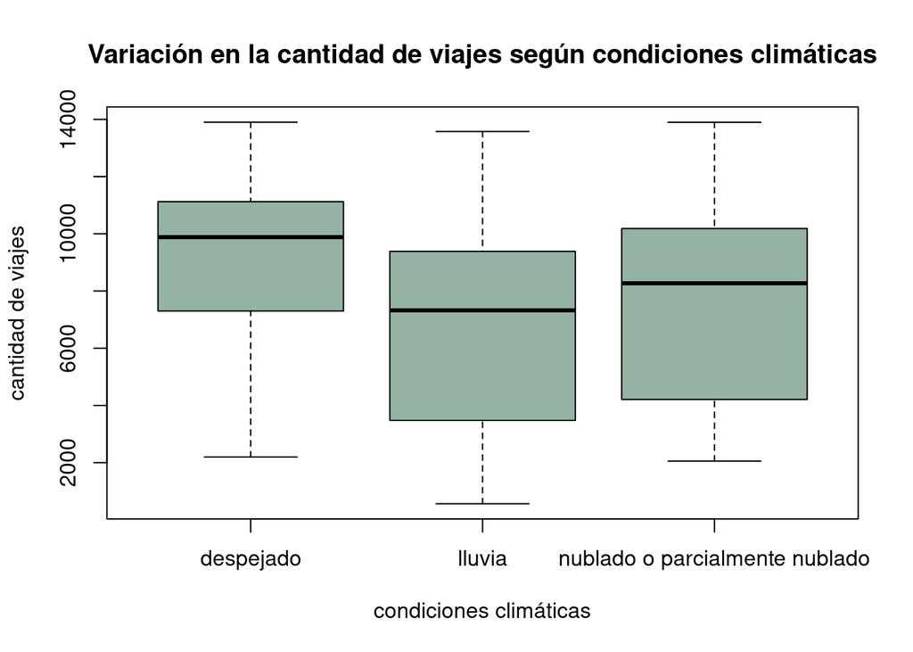

```r
boxplot(df_por_fecha$cantVIajes ~ df_por_fecha$conditions , col=rgb(0.3,0.5,0.4,0.6) , y.lim = c(0,max(df_por_fecha$conditions)),ylab="cantidad de viajes",
        xlab="condiciones climáticas", main="Variación en la cantidad de viajes según condiciones climáticas")
```

Se ve que la cantidad de viajes es mayor con el clima despejado y baja cuando este empeora.

Analisemos la relación entre la temperatura y la cantidad de viajes:

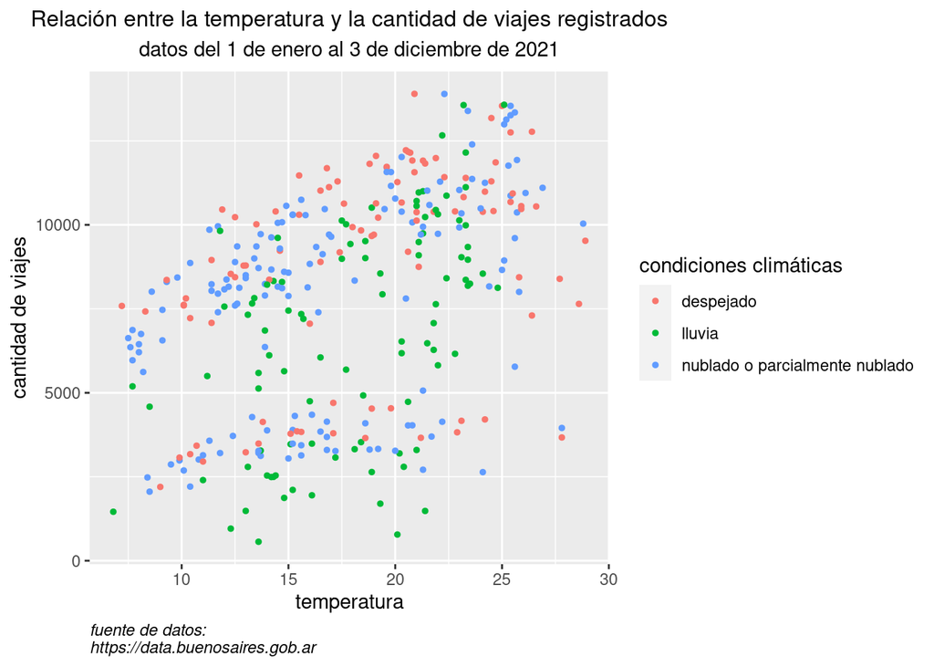

```r
ggplot(df_por_fecha, aes(x= temp, y=cantVIajes, color= conditions)) +
    geom_point(size=1) +
  xlab("temperatura") + ylab("cantidad de viajes") +
   labs(title = "Relación entre la temperatura y la cantidad de viajes registrados",
       subtitle = "datos del 1 de enero al 3 de diciembre de 2021",
       caption = "fuente de datos:
https://data.buenosaires.gob.ar",
      color = "condiciones climáticas") +
  xlab("temperatura") + ylab("cantidad de viajes") +
  theme(
    plot.title = element_text(hjust = 0.5, size = 12),
    plot.subtitle = element_text(hjust = 0.5),
    plot.caption = element_text(hjust = 0, face = "italic")
    )
```

```r
cor(df_por_fecha$temp, df_por_fecha$cantVIajes)
```

```
## [1] 0.4285869
```

Se observa una nube donde se contempla la concentración en la cantidad para las 3 condiciones climaticas. La relación entre la temperatura y la cantidad de viajes es moderada.

Veamos como se da esta relación para la humedad:

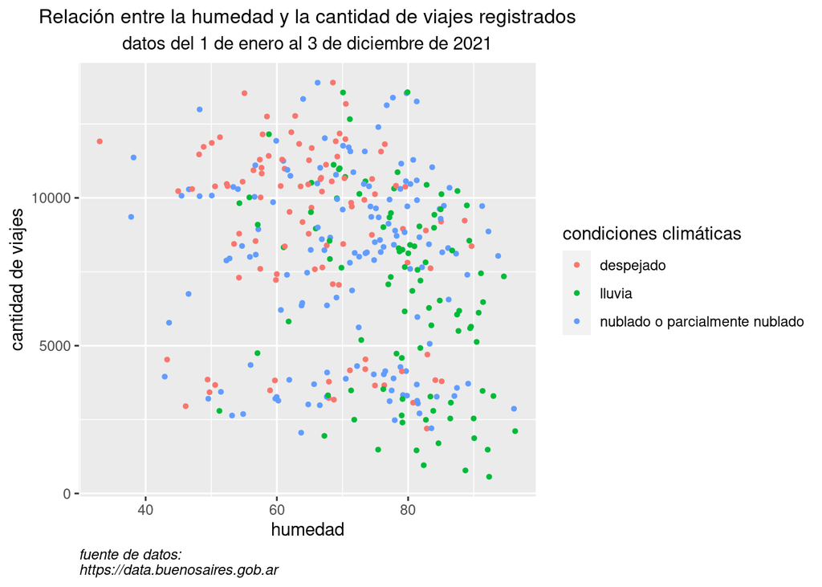

```r
ggplot(df_por_fecha, aes(x= humidity, y=cantVIajes, color= conditions)) +
    geom_point(size=1) +
  xlab("temperatura") + ylab("cantidad de viajes") +
   labs(title = "Relación entre la humedad y la cantidad de viajes registrados",
       subtitle = "datos del 1 de enero al 3 de diciembre de 2021",
       caption = "fuente de datos:
https://data.buenosaires.gob.ar",
      color = "condiciones climáticas") +
  xlab("humedad") + ylab("cantidad de viajes") +
  theme(
    plot.title = element_text(hjust = 0.5, size = 12),
    plot.subtitle = element_text(hjust = 0.5),
    plot.caption = element_text(hjust = 0, face = "italic")
    )
```

No se encuentra relación entre la cantidad de viajes registrados y la humedad.

Veamos como se da esta relación para la velocidad del viento:

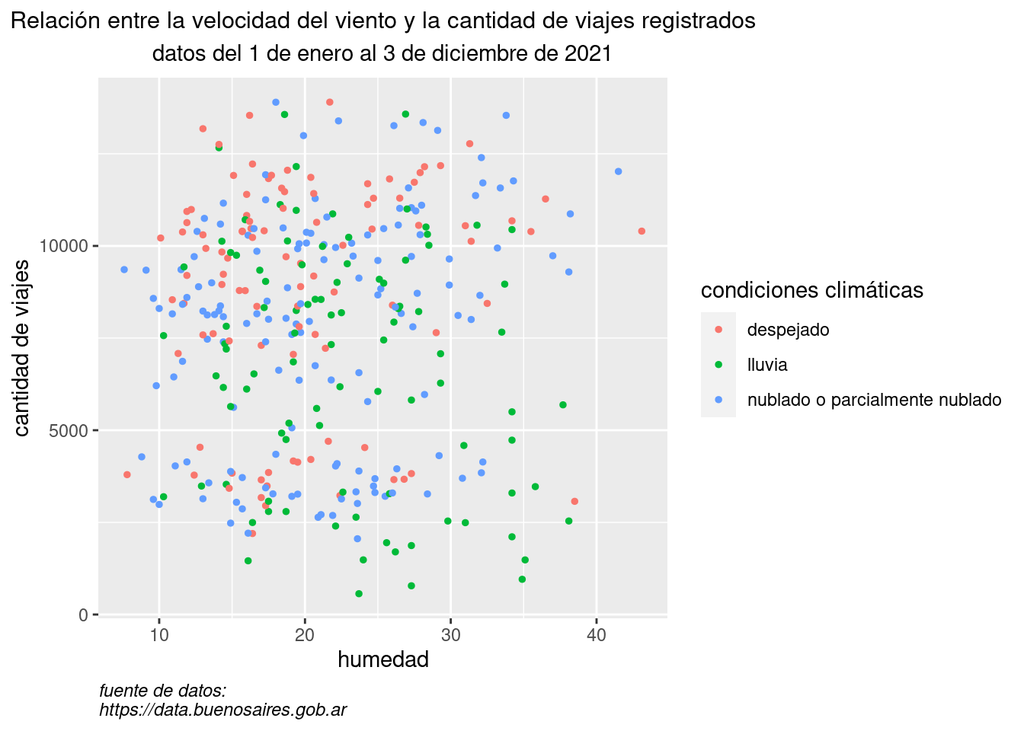

```r
ggplot(df_por_fecha, aes(x= windspeed, y=cantVIajes, color= conditions)) +
    geom_point(size=1) +
  xlab("temperatura") + ylab("cantidad de viajes") +
   labs(title = "Relación entre la velocidad del viento y la cantidad de viajes registrados",
       subtitle = "datos del 1 de enero al 3 de diciembre de 2021",
       caption = "fuente de datos:
https://data.buenosaires.gob.ar",
      color = "condiciones climáticas") +
  xlab("humedad") + ylab("cantidad de viajes") +
  theme(
    plot.title = element_text(hjust = 0.5, size = 11.5),
    plot.subtitle = element_text(hjust = 0.5),
    plot.caption = element_text(hjust = 0, face = "italic")
    )
```

No se encuentra relación entre la velocidad del viento y la cantidad de viajes.

Otra forma de ver la baja correlación entre cantViajes y las demás variables:

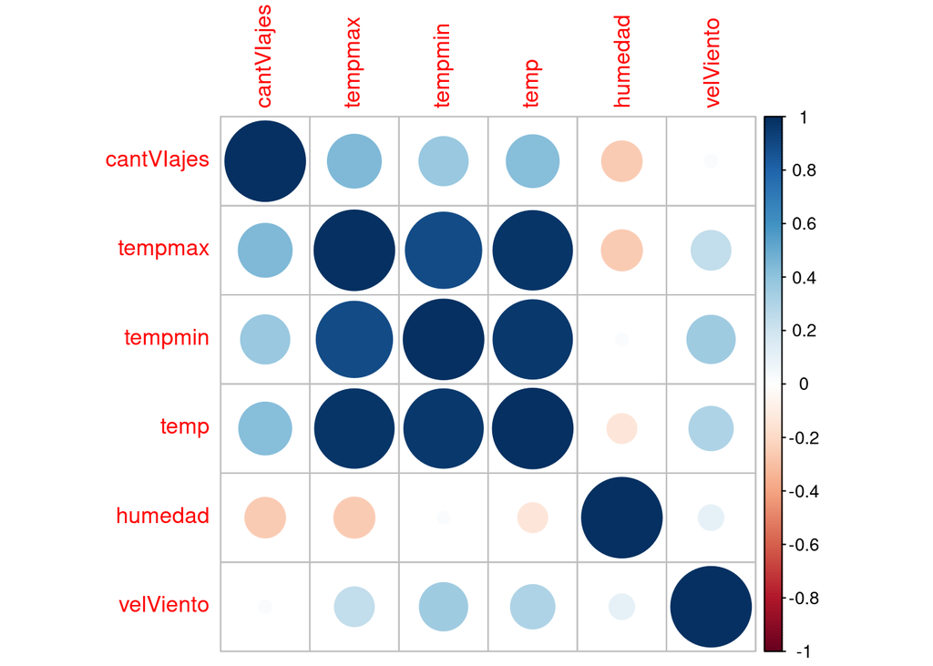

```r
df_por_fecha_climaticas <- df_por_fecha %>%
  select( cantVIajes, tempmax, tempmin, temp,humidity, windspeed)
df_por_fecha_climaticas <- df_por_fecha_climaticas %>%
  rename(humedad = humidity, velViento = windspeed)

mat_cor <-cor(df_por_fecha_climaticas)

corrplot(mat_cor)
```

```r
cor(cantidades_por_hora$hora_origen, cantidades_por_hora$cantidad)
```

```
## [1] 0.6024859
```

Las variables que tienen una correlación más alta entre si son las que están relacionadas con la temperatura. Luego tenemos que la cantidad de viajes correlaciona moderadamente con la temperatura y la temperatura máxima y en menor medida con la temperatura mínima. La correlación entre la hora de origen del viaje y la cantidad es la mas alta registrada, alcanzando un valor de 0.6.

#Conclusiones:

- el otoño, la primavera y el invierno tuvieron un marcado descenso de la cantidad de viajes los fines de semana, mientras que el verano mostró un descenso menos abrupto en estos días.
- los usuarios prefirieron condiciones climáticas mas favorables, como pueden ser los días despejados o nublados, y no aquellos en los que se dan lluvias.
- hay una correlación moderada entre las temperaturas altas y la cantidad registrada de viajes.
- no se encontró una relación entre la velocidad del viento o la humedad y la cantidad de viajes.
- las actividades de mantenimiento de las bicicletas deberían hacerse a la noche, debido al bajo uso que estas tienen a estas horas. Remover algunas bicicletas a la noche no debería causar problema a los usuarios.